# Advanced statistics for physics analysis - Exercise 4

Matteo Bortoletto, matr. 1242935

28/04/2020

# Exercise 1

The triangular distribution in the interval $(a, b)$, is given by the following:

$$f(x) = \begin{cases}
\frac{2(x-a)}{(b-a)(c-a)} & a\le x < c \\
\frac{2(b-x)}{(b-a)(b-c)} & c\le x \le b \\
0 & \text{otherwise}
\end{cases}$$
where $c \in [a, b]$.

1. Plot the function, given the interval (a, b);

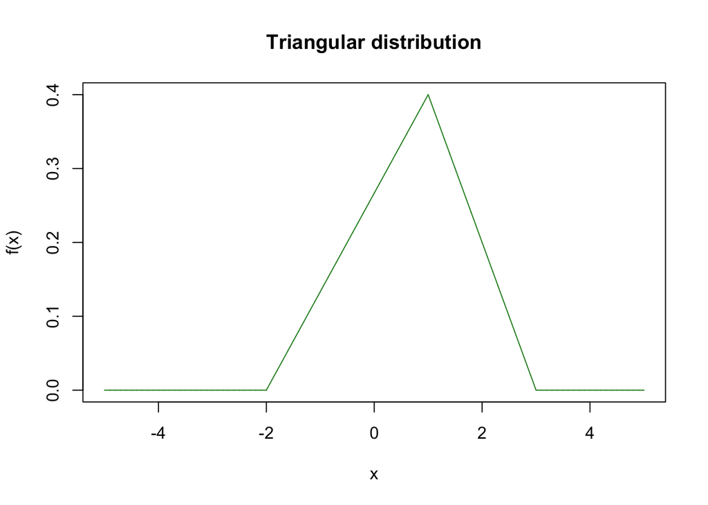

```r
f <- function(x, a, b, c) {
  func <- ifelse(a<=x & x<c, 2*(x-a)/((b-a)*(c-a)),
                 ifelse(c<=x & x<=b, 2*(b-x)/((b-a)*(b-c)), 0))
  return(func)
}

x <- seq(-5, 5, 0.001)
a <- -2
b <- 3
c <- 1

plot(x, f(x, a, b, c),
     type = "l",
     xlab = "x",
     ylab = "f(x)",
     main = "Triangular distribution",
     col = "forestgreen")
```

2. Write an algorithm to generate random numbers from the triangular distribution;

```r
set.seed(5)

cdf_f <- function(x, a, b, c) {
  func <- ifelse(x<a, 0,
                 ifelse(x<=c, (a-x)^2/((a-b)*(a-c)),
                        ifelse(x<=b, (x-a)*(a-2*b+x)/((a-b)*(b-c)), 1)))
  return(func)
}

q_f <- function(x, a, b, c) {
  func <- ifelse(x<=cdf_f(c, a, b, c), a+sqrt((b-a)*(c-a)*x),
               ifelse(x>cdf_f(c, a, b, c), b-sqrt((1-x)*(b-a)*(b-c)), 0))
  return(func)
}

r_f <- function(n, a, b, c) {
    func <- q_f(runif(n), a, b, c)
    return(func)
}
```

3. Generate $10^4$ random numbers from the distribution, show them in an histogram and superimpose the analytical curve.

```r
set.seed(5)

a <- -3
b <- 2
c <- 1
f_samples <- r_f(10000, a, b, c)
f_samples[1:10]
```

```
##  [1] -0.9989280  0.7019416  1.3553132 -0.6150494 -1.5532787  0.7444825
##  [7]  0.2494922  1.0200388  1.5336317 -1.5137092
```

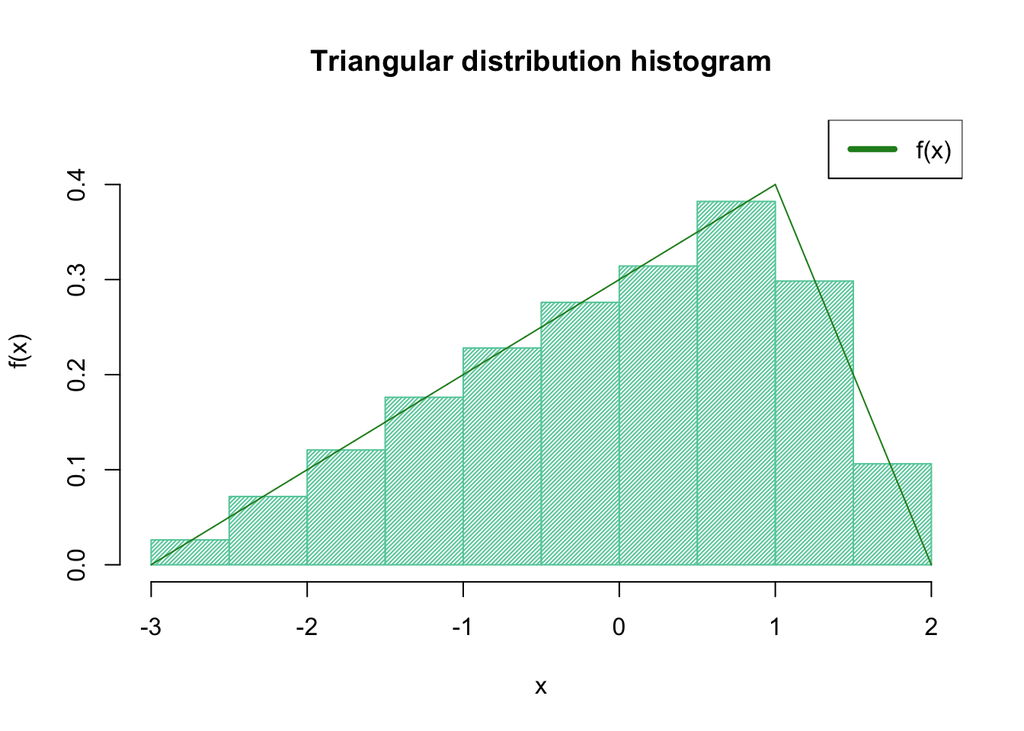

```r
hist(f_samples,
     xlab = "x",
     ylab = "f(x)",
     main = "Triangular distribution histogram",
     col = "aquamarine3",
     density = 50,
     freq = F,
     ylim = c(0, 0.45))

lines(seq(a, b, 0.001), f(seq(a, b, 0.001), a, b, c),
      col = "forestgreen")

legend("topright", c("f(x)"), lwd=4, col="forestgreen")
```

# Exercise 2

Given a discrete probability distribution defined by the following probabilities: 0.05, 0.19, 0.14, 0.17, 0.02, 0.11, 0.06, 0.05, 0.04, 0.17:

1. Plot the probability density function and the cumulative density function;

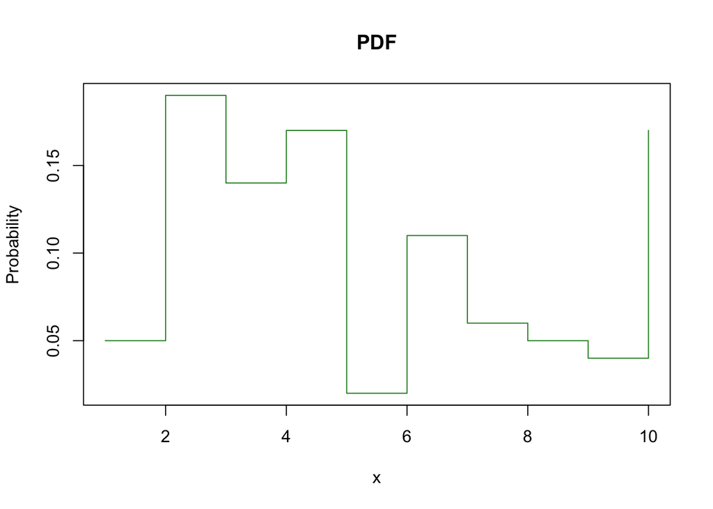

```r
p <- c(0.05, 0.19, 0.14, 0.17, 0.02, 0.11, 0.06, 0.05, 0.04, 0.17)
csum <- cumsum(p)

plot(seq(1, 10), p,
     xlab = "x",
     ylab = "Probability",
     type = "s",
     col = "forestgreen",
     main = "PDF")
```

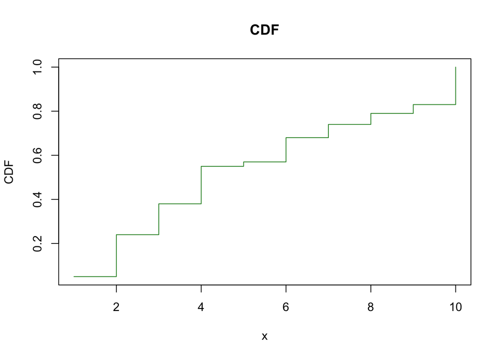

```r
plot(seq(1, 10), csum,
     xlab = "x",
     ylab = "CDF",
     type = "s",
     col = "forestgreen",
     main = "CDF")
```

2. write an algorithm to generate random numbers from the discrete probability distribution

```r
set.seed(10)

r_p <- function(n){
  unif <- runif(n)
  store <- c()
  for (i in 1:n) {
    #cat("unif[i]:", unif[i], " csum:", csum, "\n")
    v <- which.max(unif[i]<csum)
    #cat("v:", v, "\n")
    store <- c(store,v)
  }
  return(store)
}

samples <- r_p(10)
samples
```

```
##  [1] 4 3 4 7 2 2 3 3 6 4
```

# Exercise 3

Generate random variables from the following distribution:

$$f(x) = \frac{2}{\pi R^2}\sqrt{R^2-x^2}$$
where $−R\le x \le R$. Using the acceptance-rejection algorithm, assume $M = 2/(\pi R)$ and generate $10^4$ random variables, plotting them in an histogram.

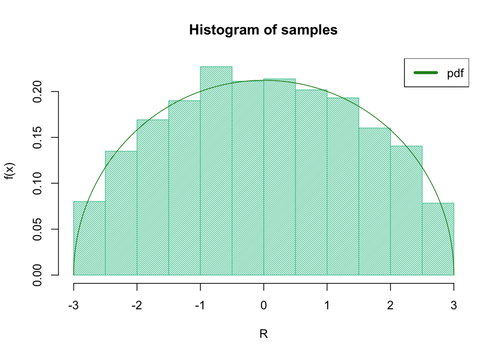

```r
f <- function(x, R) {
  func <- ifelse(x>=-R & x<= R, 2*sqrt(R^2-x^2)/(pi*R^2), 0)
  return(func)
}

r_f <- function(R) {
  a <- -R
  b <- R
  n <- 10000
  M <- 2/(pi*R)
  udist2 <- runif(n, 0, 1)
  udist1 <- runif(n, a, b)
  y <- ifelse(udist2 * M < f(udist1, R), udist1, NA)
  y.clean <- y[!is.na(y)]
  return(y.clean[1:n])
}

samples <- r_f(3)
hist(samples,
     freq = F,
     xlab = "R",
     ylab = "f(x)",
     col = "aquamarine3",
     density = 50,
     main = "Histogram of samples")

lines(seq(-3,3,0.001), f(seq(-3,3,0.001), 3),
      col = "forestgreen")

legend("topright", c("pdf"), lwd=4, col="forestgreen")
```

# Exercise 4

An important property of the gamma distribution is the so-called reproductive property: given a sequence of independent random variables $X_j \sim \Gamma(\alpha_j,\beta)$, it follows that

$$Y = \sum_{j=1}^n X_j \longrightarrow \Gamma(\alpha,\beta), \quad \text{where } \alpha = \sum_{j=1}^n \alpha_j$$
If $\alpha = m$ is an integer, a random variable from gamma distribution $\Gamma(m,\beta)$ (also known as Erlang distribution) can be obtained by summing $m$ independent exponential random variables $X_j \sim \text{Exp}(\beta)$:

$$Y = \beta\sum_{j=1}^n (-\ln U_j) = -\beta\prod_{j=1}^n U_j$$
write an algorithm to sample variables from an Erlang distribution $\Gamma(m,\beta)$.

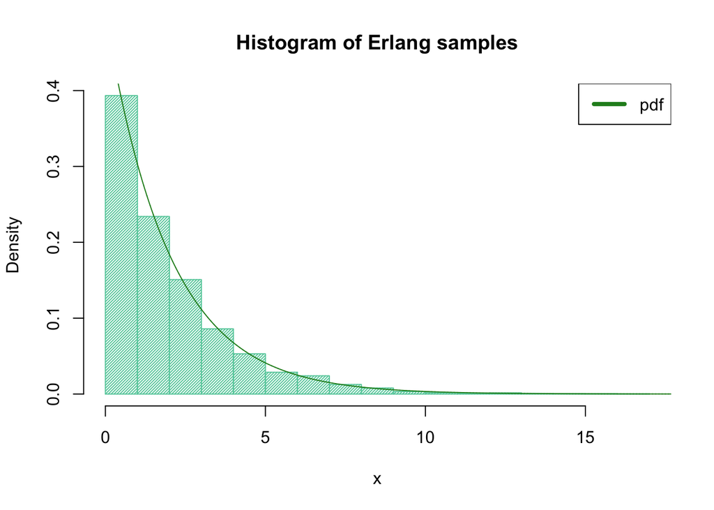

```r
r_erlang <- function(n, b) {
  unif <- runif(n)
  e <- -b*log(unif)
  return(e)
}

m <- 3
b <- 0.5
n <- 1e4
x <- seq(0, 100, 0.001)

hist(r_erlang(n, 2),
     freq = FALSE,
     xlab = "x",
     main = "Histogram of Erlang samples",
     col = "aquamarine3",
     density = 50)

lines(x, dgamma(x, 1, b),
      col = "forestgreen")

legend("topright", c("pdf"), lwd=4, col="forestgreen")
```

# Exercise 5

One of the first random number generators was proposed by von Neumann, the so-called middle square algorithm. Write R code to implement this type of generator and, given a fixed digit number input, square it an remove the leading and trailing digits, in order to return a number with the same number of digits as the original number.

*Suggestion*: after having squared the number, convert it to a list of characters

`(number <- unlist(strsplit(as.character(x.squared),"")))`

and, after having removed the head and tail of the list, convert it back to a number

`(as.numeric(paste(number.after.trimming, collapse="")))`

```r
seed <- 9172886649
l <- 5
x <- seed
generated <- c(x)

for(i in 1:10){
    x.squared <- x^2
    number <- unlist(strsplit(as.character(x.squared),""))
    middle <- ceiling(length(number)/2)
    start <- middle - l + 1
    end <- middle + l
    number.after.trimming <- number[start:end]
    x <- as.numeric(paste(number.after.trimming, collapse=""))
    generated <- c(generated, x)
}

cat(generated)
```

```
## 9172886649 8494754024 8459282641 4628003239 4139801944 9601355461 266884745 7467113715 7872327410 5388502373 9578238266
```